# Risk Factor Analysis

## Outcome Variable

**Outcome Variable:** ever_swasted

## Predictor Variables

**Intervention Variable:** birthwt

**Adjustment Set:**

unadjusted

## Stratifying Variables

The analysis was stratified on these variable(s):

- agecat
- studyid
- country

## Data Summary

| agecat | studyid | country | birthwt | ever_swasted | n_cell | n |
| --- | --- | --- | --- | --- | --- | --- |
| 0-24 months (no birth wast) | ki0047075b-MAL-ED | BANGLADESH | Normal or high birthweight | 0 | 194 | 255 |
| 0-24 months (no birth wast) | ki0047075b-MAL-ED | BANGLADESH | Normal or high birthweight | 1 | 9 | 255 |
| 0-24 months (no birth wast) | ki0047075b-MAL-ED | BANGLADESH | Low birth weight | 0 | 49 | 255 |
| 0-24 months (no birth wast) | ki0047075b-MAL-ED | BANGLADESH | Low birth weight | 1 | 3 | 255 |
| 0-24 months (no birth wast) | ki0047075b-MAL-ED | BRAZIL | Normal or high birthweight | 0 | 214 | 229 |
| 0-24 months (no birth wast) | ki0047075b-MAL-ED | BRAZIL | Normal or high birthweight | 1 | 3 | 229 |
| 0-24 months (no birth wast) | ki0047075b-MAL-ED | BRAZIL | Low birth weight | 0 | 12 | 229 |
| 0-24 months (no birth wast) | ki0047075b-MAL-ED | BRAZIL | Low birth weight | 1 | 0 | 229 |
| 0-24 months (no birth wast) | ki0047075b-MAL-ED | INDIA | Normal or high birthweight | 0 | 189 | 234 |
| 0-24 months (no birth wast) | ki0047075b-MAL-ED | INDIA | Normal or high birthweight | 1 | 9 | 234 |
| 0-24 months (no birth wast) | ki0047075b-MAL-ED | INDIA | Low birth weight | 0 | 36 | 234 |
| 0-24 months (no birth wast) | ki0047075b-MAL-ED | INDIA | Low birth weight | 1 | 0 | 234 |
| 0-24 months (no birth wast) | ki0047075b-MAL-ED | NEPAL | Normal or high birthweight | 0 | 209 | 231 |
| 0-24 months (no birth wast) | ki0047075b-MAL-ED | NEPAL | Normal or high birthweight | 1 | 1 | 231 |
| 0-24 months (no birth wast) | ki0047075b-MAL-ED | NEPAL | Low birth weight | 0 | 21 | 231 |
| 0-24 months (no birth wast) | ki0047075b-MAL-ED | NEPAL | Low birth weight | 1 | 0 | 231 |
| 0-24 months (no birth wast) | ki0047075b-MAL-ED | PERU | Normal or high birthweight | 0 | 275 | 296 |
| 0-24 months (no birth wast) | ki0047075b-MAL-ED | PERU | Normal or high birthweight | 1 | 3 | 296 |
| 0-24 months (no birth wast) | ki0047075b-MAL-ED | PERU | Low birth weight | 0 | 18 | 296 |
| 0-24 months (no birth wast) | ki0047075b-MAL-ED | PERU | Low birth weight | 1 | 0 | 296 |
| 0-24 months (no birth wast) | ki0047075b-MAL-ED | SOUTH AFRICA | Normal or high birthweight | 0 | 264 | 294 |
| 0-24 months (no birth wast) | ki0047075b-MAL-ED | SOUTH AFRICA | Normal or high birthweight | 1 | 10 | 294 |
| 0-24 months (no birth wast) | ki0047075b-MAL-ED | SOUTH AFRICA | Low birth weight | 0 | 19 | 294 |
| 0-24 months (no birth wast) | ki0047075b-MAL-ED | SOUTH AFRICA | Low birth weight | 1 | 1 | 294 |
| 0-24 months (no birth wast) | ki0047075b-MAL-ED | TANZANIA, UNITED REPUBLIC OF | Normal or high birthweight | 0 | 126 | 135 |
| 0-24 months (no birth wast) | ki0047075b-MAL-ED | TANZANIA, UNITED REPUBLIC OF | Normal or high birthweight | 1 | 2 | 135 |
| 0-24 months (no birth wast) | ki0047075b-MAL-ED | TANZANIA, UNITED REPUBLIC OF | Low birth weight | 0 | 7 | 135 |
| 0-24 months (no birth wast) | ki0047075b-MAL-ED | TANZANIA, UNITED REPUBLIC OF | Low birth weight | 1 | 0 | 135 |
| 0-24 months (no birth wast) | ki1000108-CMC-V-BCS-2002 | INDIA | Normal or high birthweight | 0 | 278 | 368 |
| 0-24 months (no birth wast) | ki1000108-CMC-V-BCS-2002 | INDIA | Normal or high birthweight | 1 | 50 | 368 |

[output cut: 318 more lines]

The following strata were considered:

- agecat: 0-24 months (no birth wast), studyid: ki0047075b-MAL-ED, country: BANGLADESH
- agecat: 0-24 months (no birth wast), studyid: ki0047075b-MAL-ED, country: BRAZIL
- agecat: 0-24 months (no birth wast), studyid: ki0047075b-MAL-ED, country: INDIA
- agecat: 0-24 months (no birth wast), studyid: ki0047075b-MAL-ED, country: NEPAL
- agecat: 0-24 months (no birth wast), studyid: ki0047075b-MAL-ED, country: PERU
- agecat: 0-24 months (no birth wast), studyid: ki0047075b-MAL-ED, country: SOUTH AFRICA
- agecat: 0-24 months (no birth wast), studyid: ki0047075b-MAL-ED, country: TANZANIA, UNITED REPUBLIC OF
- agecat: 0-24 months (no birth wast), studyid: ki1000108-CMC-V-BCS-2002, country: INDIA
- agecat: 0-24 months (no birth wast), studyid: ki1000108-IRC, country: INDIA
- agecat: 0-24 months (no birth wast), studyid: ki1000109-EE, country: PAKISTAN
- agecat: 0-24 months (no birth wast), studyid: ki1000109-ResPak, country: PAKISTAN
- agecat: 0-24 months (no birth wast), studyid: ki1000304b-SAS-CompFeed, country: INDIA
- agecat: 0-24 months (no birth wast), studyid: ki1017093-NIH-Birth, country: BANGLADESH
- agecat: 0-24 months (no birth wast), studyid: ki1017093b-PROVIDE, country: BANGLADESH
- agecat: 0-24 months (no birth wast), studyid: ki1017093c-NIH-Crypto, country: BANGLADESH
- agecat: 0-24 months (no birth wast), studyid: ki1066203-TanzaniaChild2, country: TANZANIA, UNITED REPUBLIC OF
- agecat: 0-24 months (no birth wast), studyid: ki1101329-Keneba, country: GAMBIA
- agecat: 0-24 months (no birth wast), studyid: ki1114097-CMIN, country: BANGLADESH
- agecat: 0-24 months (no birth wast), studyid: ki1114097-CMIN, country: BRAZIL
- agecat: 0-24 months (no birth wast), studyid: ki1114097-CMIN, country: GUINEA-BISSAU
- agecat: 0-24 months (no birth wast), studyid: ki1114097-CMIN, country: PERU
- agecat: 0-24 months (no birth wast), studyid: ki1114097-CONTENT, country: PERU
- agecat: 0-24 months (no birth wast), studyid: ki1119695-PROBIT, country: BELARUS
- agecat: 0-24 months (no birth wast), studyid: ki1126311-ZVITAMBO, country: ZIMBABWE
- agecat: 0-24 months (no birth wast), studyid: ki1135781-COHORTS, country: GUATEMALA
- agecat: 0-24 months (no birth wast), studyid: ki1135781-COHORTS, country: INDIA
- agecat: 0-24 months (no birth wast), studyid: ki1135781-COHORTS, country: PHILIPPINES
- agecat: 0-24 months (no birth wast), studyid: kiGH5241-JiVitA-3, country: BANGLADESH
- agecat: 0-24 months (no birth wast), studyid: kiGH5241-JiVitA-4, country: BANGLADESH
- agecat: 0-6 months (no birth wast), studyid: ki0047075b-MAL-ED, country: BANGLADESH
- agecat: 0-6 months (no birth wast), studyid: ki0047075b-MAL-ED, country: BRAZIL
- agecat: 0-6 months (no birth wast), studyid: ki0047075b-MAL-ED, country: INDIA
- agecat: 0-6 months (no birth wast), studyid: ki0047075b-MAL-ED, country: NEPAL
- agecat: 0-6 months (no birth wast), studyid: ki0047075b-MAL-ED, country: PERU
- agecat: 0-6 months (no birth wast), studyid: ki0047075b-MAL-ED, country: SOUTH AFRICA
- agecat: 0-6 months (no birth wast), studyid: ki0047075b-MAL-ED, country: TANZANIA, UNITED REPUBLIC OF
- agecat: 0-6 months (no birth wast), studyid: ki1000108-CMC-V-BCS-2002, country: INDIA
- agecat: 0-6 months (no birth wast), studyid: ki1000108-IRC, country: INDIA
- agecat: 0-6 months (no birth wast), studyid: ki1000109-EE, country: PAKISTAN
- agecat: 0-6 months (no birth wast), studyid: ki1000109-ResPak, country: PAKISTAN
- agecat: 0-6 months (no birth wast), studyid: ki1000304b-SAS-CompFeed, country: INDIA
- agecat: 0-6 months (no birth wast), studyid: ki1017093-NIH-Birth, country: BANGLADESH
- agecat: 0-6 months (no birth wast), studyid: ki1017093b-PROVIDE, country: BANGLADESH
- agecat: 0-6 months (no birth wast), studyid: ki1017093c-NIH-Crypto, country: BANGLADESH
- agecat: 0-6 months (no birth wast), studyid: ki1066203-TanzaniaChild2, country: TANZANIA, UNITED REPUBLIC OF
- agecat: 0-6 months (no birth wast), studyid: ki1101329-Keneba, country: GAMBIA
- agecat: 0-6 months (no birth wast), studyid: ki1114097-CMIN, country: BANGLADESH
- agecat: 0-6 months (no birth wast), studyid: ki1114097-CMIN, country: BRAZIL
- agecat: 0-6 months (no birth wast), studyid: ki1114097-CMIN, country: GUINEA-BISSAU
- agecat: 0-6 months (no birth wast), studyid: ki1114097-CMIN, country: PERU
- agecat: 0-6 months (no birth wast), studyid: ki1114097-CONTENT, country: PERU
- agecat: 0-6 months (no birth wast), studyid: ki1119695-PROBIT, country: BELARUS
- agecat: 0-6 months (no birth wast), studyid: ki1126311-ZVITAMBO, country: ZIMBABWE
- agecat: 0-6 months (no birth wast), studyid: ki1135781-COHORTS, country: GUATEMALA
- agecat: 0-6 months (no birth wast), studyid: ki1135781-COHORTS, country: INDIA
- agecat: 0-6 months (no birth wast), studyid: ki1135781-COHORTS, country: PHILIPPINES
- agecat: 0-6 months (no birth wast), studyid: kiGH5241-JiVitA-3, country: BANGLADESH
- agecat: 0-6 months (no birth wast), studyid: kiGH5241-JiVitA-4, country: BANGLADESH
- agecat: 6-24 months, studyid: ki0047075b-MAL-ED, country: BANGLADESH
- agecat: 6-24 months, studyid: ki0047075b-MAL-ED, country: BRAZIL
- agecat: 6-24 months, studyid: ki0047075b-MAL-ED, country: INDIA
- agecat: 6-24 months, studyid: ki0047075b-MAL-ED, country: NEPAL
- agecat: 6-24 months, studyid: ki0047075b-MAL-ED, country: PERU
- agecat: 6-24 months, studyid: ki0047075b-MAL-ED, country: SOUTH AFRICA
- agecat: 6-24 months, studyid: ki0047075b-MAL-ED, country: TANZANIA, UNITED REPUBLIC OF
- agecat: 6-24 months, studyid: ki1000108-CMC-V-BCS-2002, country: INDIA
- agecat: 6-24 months, studyid: ki1000108-IRC, country: INDIA
- agecat: 6-24 months, studyid: ki1000109-EE, country: PAKISTAN
- agecat: 6-24 months, studyid: ki1000109-ResPak, country: PAKISTAN
- agecat: 6-24 months, studyid: ki1000304b-SAS-CompFeed, country: INDIA
- agecat: 6-24 months, studyid: ki1017093-NIH-Birth, country: BANGLADESH
- agecat: 6-24 months, studyid: ki1017093b-PROVIDE, country: BANGLADESH
- agecat: 6-24 months, studyid: ki1017093c-NIH-Crypto, country: BANGLADESH
- agecat: 6-24 months, studyid: ki1066203-TanzaniaChild2, country: TANZANIA, UNITED REPUBLIC OF
- agecat: 6-24 months, studyid: ki1101329-Keneba, country: GAMBIA
- agecat: 6-24 months, studyid: ki1114097-CMIN, country: BANGLADESH
- agecat: 6-24 months, studyid: ki1114097-CMIN, country: BRAZIL
- agecat: 6-24 months, studyid: ki1114097-CMIN, country: GUINEA-BISSAU
- agecat: 6-24 months, studyid: ki1114097-CMIN, country: PERU
- agecat: 6-24 months, studyid: ki1114097-CONTENT, country: PERU
- agecat: 6-24 months, studyid: ki1119695-PROBIT, country: BELARUS
- agecat: 6-24 months, studyid: ki1126311-ZVITAMBO, country: ZIMBABWE
- agecat: 6-24 months, studyid: ki1135781-COHORTS, country: GUATEMALA
- agecat: 6-24 months, studyid: ki1135781-COHORTS, country: INDIA
- agecat: 6-24 months, studyid: ki1135781-COHORTS, country: PHILIPPINES
- agecat: 6-24 months, studyid: kiGH5241-JiVitA-3, country: BANGLADESH
- agecat: 6-24 months, studyid: kiGH5241-JiVitA-4, country: BANGLADESH

### Dropped Strata

Some strata were dropped due to rare outcomes:

- agecat: 0-24 months (no birth wast), studyid: ki0047075b-MAL-ED, country: BANGLADESH
- agecat: 0-24 months (no birth wast), studyid: ki0047075b-MAL-ED, country: BRAZIL
- agecat: 0-24 months (no birth wast), studyid: ki0047075b-MAL-ED, country: INDIA
- agecat: 0-24 months (no birth wast), studyid: ki0047075b-MAL-ED, country: NEPAL
- agecat: 0-24 months (no birth wast), studyid: ki0047075b-MAL-ED, country: PERU
- agecat: 0-24 months (no birth wast), studyid: ki0047075b-MAL-ED, country: SOUTH AFRICA
- agecat: 0-24 months (no birth wast), studyid: ki0047075b-MAL-ED, country: TANZANIA, UNITED REPUBLIC OF
- agecat: 0-24 months (no birth wast), studyid: ki1000109-ResPak, country: PAKISTAN
- agecat: 0-24 months (no birth wast), studyid: ki1114097-CMIN, country: BANGLADESH
- agecat: 0-24 months (no birth wast), studyid: ki1114097-CMIN, country: BRAZIL
- agecat: 0-24 months (no birth wast), studyid: ki1114097-CMIN, country: GUINEA-BISSAU
- agecat: 0-24 months (no birth wast), studyid: ki1114097-CMIN, country: PERU
- agecat: 0-24 months (no birth wast), studyid: ki1114097-CONTENT, country: PERU
- agecat: 0-24 months (no birth wast), studyid: ki1119695-PROBIT, country: BELARUS
- agecat: 0-24 months (no birth wast), studyid: ki1135781-COHORTS, country: GUATEMALA
- agecat: 0-6 months (no birth wast), studyid: ki0047075b-MAL-ED, country: BANGLADESH
- agecat: 0-6 months (no birth wast), studyid: ki0047075b-MAL-ED, country: BRAZIL
- agecat: 0-6 months (no birth wast), studyid: ki0047075b-MAL-ED, country: INDIA
- agecat: 0-6 months (no birth wast), studyid: ki0047075b-MAL-ED, country: NEPAL
- agecat: 0-6 months (no birth wast), studyid: ki0047075b-MAL-ED, country: PERU
- agecat: 0-6 months (no birth wast), studyid: ki0047075b-MAL-ED, country: SOUTH AFRICA
- agecat: 0-6 months (no birth wast), studyid: ki0047075b-MAL-ED, country: TANZANIA, UNITED REPUBLIC OF
- agecat: 0-6 months (no birth wast), studyid: ki1000108-CMC-V-BCS-2002, country: INDIA
- agecat: 0-6 months (no birth wast), studyid: ki1000109-EE, country: PAKISTAN
- agecat: 0-6 months (no birth wast), studyid: ki1000109-ResPak, country: PAKISTAN
- agecat: 0-6 months (no birth wast), studyid: ki1017093-NIH-Birth, country: BANGLADESH
- agecat: 0-6 months (no birth wast), studyid: ki1017093b-PROVIDE, country: BANGLADESH
- agecat: 0-6 months (no birth wast), studyid: ki1017093c-NIH-Crypto, country: BANGLADESH
- agecat: 0-6 months (no birth wast), studyid: ki1066203-TanzaniaChild2, country: TANZANIA, UNITED REPUBLIC OF
- agecat: 0-6 months (no birth wast), studyid: ki1114097-CMIN, country: BANGLADESH
- agecat: 0-6 months (no birth wast), studyid: ki1114097-CMIN, country: BRAZIL
- agecat: 0-6 months (no birth wast), studyid: ki1114097-CMIN, country: GUINEA-BISSAU
- agecat: 0-6 months (no birth wast), studyid: ki1114097-CMIN, country: PERU
- agecat: 0-6 months (no birth wast), studyid: ki1114097-CONTENT, country: PERU
- agecat: 0-6 months (no birth wast), studyid: ki1119695-PROBIT, country: BELARUS
- agecat: 0-6 months (no birth wast), studyid: ki1135781-COHORTS, country: GUATEMALA
- agecat: 0-6 months (no birth wast), studyid: kiGH5241-JiVitA-4, country: BANGLADESH
- agecat: 6-24 months, studyid: ki0047075b-MAL-ED, country: BANGLADESH
- agecat: 6-24 months, studyid: ki0047075b-MAL-ED, country: BRAZIL
- agecat: 6-24 months, studyid: ki0047075b-MAL-ED, country: INDIA
- agecat: 6-24 months, studyid: ki0047075b-MAL-ED, country: NEPAL
- agecat: 6-24 months, studyid: ki0047075b-MAL-ED, country: PERU
- agecat: 6-24 months, studyid: ki0047075b-MAL-ED, country: SOUTH AFRICA
- agecat: 6-24 months, studyid: ki0047075b-MAL-ED, country: TANZANIA, UNITED REPUBLIC OF
- agecat: 6-24 months, studyid: ki1000109-ResPak, country: PAKISTAN
- agecat: 6-24 months, studyid: ki1114097-CMIN, country: BANGLADESH
- agecat: 6-24 months, studyid: ki1114097-CMIN, country: BRAZIL
- agecat: 6-24 months, studyid: ki1114097-CMIN, country: GUINEA-BISSAU
- agecat: 6-24 months, studyid: ki1114097-CMIN, country: PERU
- agecat: 6-24 months, studyid: ki1114097-CONTENT, country: PERU
- agecat: 6-24 months, studyid: ki1119695-PROBIT, country: BELARUS
- agecat: 6-24 months, studyid: ki1135781-COHORTS, country: GUATEMALA

## Methods Detail

We’re interested in the causal parameters $E[Y_a]$ for all values of $a \in \mathcal{A}$. These parameters represent the mean outcome if, possibly contrary to fact, we intervened to set all units to have $A=a$. Under the randomization and positivity assumptions, these are identified by the statistical parameters $\psi_a=E_W[E_{Y|A,W}(Y|A=a,W)]$. In addition, we’re interested in the mean of $Y$, $E[Y]$ under no intervention (the observed mean). We will estimate these parameters by using SuperLearner to fit the relevant likelihood factors – $E_{Y|A,W}(Y|A=a,W)$ and $p(A=a|W)$, and then updating our likelihood fit using a joint TMLE.

For unadjusted analyses ($W=\{\}$), initial likelihoods were estimated using Lrnr_glm to estimate the simple $E(Y|A)$ and Lrnr_mean to estimate $p(A)$. For adjusted analyses, a small library containing Lrnr_glmnet, Lrnr_xgboost, and Lrnr_mean was used.

Having estimated these parameters, we will then use the delta method to estimate relative risks and attributable risks relative to a prespecified baseline level of $A$.

# Results Detail

## Results Plots

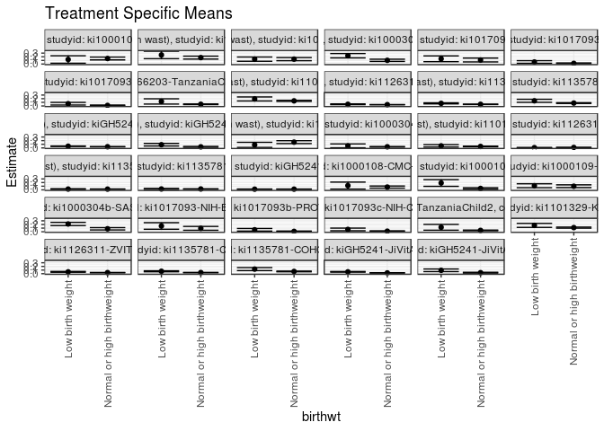

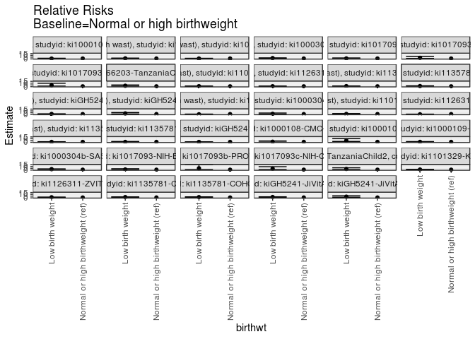

[figure not shown]

[figure not shown]

## Results Table

### Parameter: TSM

| agecat | studyid | country | intervention_level | baseline_level | estimate | ci_lower | ci_upper |
| --- | --- | --- | --- | --- | --- | --- | --- |
| 0-24 months (no birth wast) | ki1000108-CMC-V-BCS-2002 | INDIA | Normal or high birthweight | NA | 0.1524390 | 0.1134865 | 0.1913915 |
| 0-24 months (no birth wast) | ki1000108-CMC-V-BCS-2002 | INDIA | Low birth weight | NA | 0.1250000 | 0.0223715 | 0.2276285 |
| 0-24 months (no birth wast) | ki1000108-IRC | INDIA | Normal or high birthweight | NA | 0.1769912 | 0.1363131 | 0.2176692 |
| 0-24 months (no birth wast) | ki1000108-IRC | INDIA | Low birth weight | NA | 0.2500000 | 0.1469546 | 0.3530454 |
| 0-24 months (no birth wast) | ki1000109-EE | PAKISTAN | Normal or high birthweight | NA | 0.1352459 | 0.0922786 | 0.1782132 |
| 0-24 months (no birth wast) | ki1000109-EE | PAKISTAN | Low birth weight | NA | 0.1353383 | 0.0771237 | 0.1935530 |
| 0-24 months (no birth wast) | ki1000304b-SAS-CompFeed | INDIA | Normal or high birthweight | NA | 0.1024931 | 0.0717609 | 0.1332253 |
| 0-24 months (no birth wast) | ki1000304b-SAS-CompFeed | INDIA | Low birth weight | NA | 0.2291667 | 0.1696459 | 0.2886874 |
| 0-24 months (no birth wast) | ki1017093-NIH-Birth | BANGLADESH | Normal or high birthweight | NA | 0.1111111 | 0.0579719 | 0.1642503 |
| 0-24 months (no birth wast) | ki1017093-NIH-Birth | BANGLADESH | Low birth weight | NA | 0.1447368 | 0.0654480 | 0.2240257 |
| 0-24 months (no birth wast) | ki1017093b-PROVIDE | BANGLADESH | Normal or high birthweight | NA | 0.0189394 | 0.0073041 | 0.0305747 |
| 0-24 months (no birth wast) | ki1017093b-PROVIDE | BANGLADESH | Low birth weight | NA | 0.0566038 | 0.0206590 | 0.0925485 |
| 0-24 months (no birth wast) | ki1017093c-NIH-Crypto | BANGLADESH | Normal or high birthweight | NA | 0.0155440 | 0.0054613 | 0.0256267 |
| 0-24 months (no birth wast) | ki1017093c-NIH-Crypto | BANGLADESH | Low birth weight | NA | 0.0628571 | 0.0268741 | 0.0988402 |
| 0-24 months (no birth wast) | ki1066203-TanzaniaChild2 | TANZANIA, UNITED REPUBLIC OF | Normal or high birthweight | NA | 0.0473892 | 0.0386642 | 0.0561142 |
| 0-24 months (no birth wast) | ki1066203-TanzaniaChild2 | TANZANIA, UNITED REPUBLIC OF | Low birth weight | NA | 0.1250000 | 0.0525140 | 0.1974860 |
| 0-24 months (no birth wast) | ki1101329-Keneba | GAMBIA | Normal or high birthweight | NA | 0.1409853 | 0.1253665 | 0.1566042 |
| 0-24 months (no birth wast) | ki1101329-Keneba | GAMBIA | Low birth weight | NA | 0.1928934 | 0.1377819 | 0.2480049 |
| 0-24 months (no birth wast) | ki1126311-ZVITAMBO | ZIMBABWE | Normal or high birthweight | NA | 0.0364091 | 0.0328754 | 0.0399428 |
| 0-24 months (no birth wast) | ki1126311-ZVITAMBO | ZIMBABWE | Low birth weight | NA | 0.0462392 | 0.0360189 | 0.0564595 |
| 0-24 months (no birth wast) | ki1135781-COHORTS | INDIA | Normal or high birthweight | NA | 0.0458924 | 0.0402558 | 0.0515290 |
| 0-24 months (no birth wast) | ki1135781-COHORTS | INDIA | Low birth weight | NA | 0.0719603 | 0.0573924 | 0.0865282 |
| 0-24 months (no birth wast) | ki1135781-COHORTS | PHILIPPINES | Normal or high birthweight | NA | 0.0799087 | 0.0695400 | 0.0902773 |
| 0-24 months (no birth wast) | ki1135781-COHORTS | PHILIPPINES | Low birth weight | NA | 0.1423221 | 0.1004075 | 0.1842367 |
| 0-24 months (no birth wast) | kiGH5241-JiVitA-3 | BANGLADESH | Normal or high birthweight | NA | 0.0324186 | 0.0281366 | 0.0367007 |
| 0-24 months (no birth wast) | kiGH5241-JiVitA-3 | BANGLADESH | Low birth weight | NA | 0.0468110 | 0.0401753 | 0.0534467 |
| 0-24 months (no birth wast) | kiGH5241-JiVitA-4 | BANGLADESH | Normal or high birthweight | NA | 0.0291153 | 0.0169189 | 0.0413117 |
| 0-24 months (no birth wast) | kiGH5241-JiVitA-4 | BANGLADESH | Low birth weight | NA | 0.0880282 | 0.0524520 | 0.1236043 |
| 0-6 months (no birth wast) | ki1000108-IRC | INDIA | Normal or high birthweight | NA | 0.1585366 | 0.1189586 | 0.1981146 |
| 0-6 months (no birth wast) | ki1000108-IRC | INDIA | Low birth weight | NA | 0.0833333 | 0.0133092 | 0.1533575 |
| 0-6 months (no birth wast) | ki1000304b-SAS-CompFeed | INDIA | Normal or high birthweight | NA | 0.0305556 | 0.0223354 | 0.0387757 |
| 0-6 months (no birth wast) | ki1000304b-SAS-CompFeed | INDIA | Low birth weight | NA | 0.0561798 | 0.0036418 | 0.1087178 |
| 0-6 months (no birth wast) | ki1101329-Keneba | GAMBIA | Normal or high birthweight | NA | 0.0404789 | 0.0312535 | 0.0497044 |
| 0-6 months (no birth wast) | ki1101329-Keneba | GAMBIA | Low birth weight | NA | 0.0568182 | 0.0226088 | 0.0910276 |
| 0-6 months (no birth wast) | ki1126311-ZVITAMBO | ZIMBABWE | Normal or high birthweight | NA | 0.0121694 | 0.0100142 | 0.0143245 |
| 0-6 months (no birth wast) | ki1126311-ZVITAMBO | ZIMBABWE | Low birth weight | NA | 0.0068399 | 0.0026149 | 0.0110650 |
| 0-6 months (no birth wast) | ki1135781-COHORTS | INDIA | Normal or high birthweight | NA | 0.0196480 | 0.0157561 | 0.0235398 |
| 0-6 months (no birth wast) | ki1135781-COHORTS | INDIA | Low birth weight | NA | 0.0210210 | 0.0121246 | 0.0299175 |
| 0-6 months (no birth wast) | ki1135781-COHORTS | PHILIPPINES | Normal or high birthweight | NA | 0.0231481 | 0.0173581 | 0.0289382 |
| 0-6 months (no birth wast) | ki1135781-COHORTS | PHILIPPINES | Low birth weight | NA | 0.0231660 | 0.0048424 | 0.0414896 |
| 0-6 months (no birth wast) | kiGH5241-JiVitA-3 | BANGLADESH | Normal or high birthweight | NA | 0.0186232 | 0.0152706 | 0.0219758 |
| 0-6 months (no birth wast) | kiGH5241-JiVitA-3 | BANGLADESH | Low birth weight | NA | 0.0179140 | 0.0138973 | 0.0219307 |
| 6-24 months | ki1000108-CMC-V-BCS-2002 | INDIA | Normal or high birthweight | NA | 0.0757576 | 0.0471698 | 0.1043453 |
| 6-24 months | ki1000108-CMC-V-BCS-2002 | INDIA | Low birth weight | NA | 0.1162791 | 0.0203379 | 0.2122203 |
| 6-24 months | ki1000108-IRC | INDIA | Normal or high birthweight | NA | 0.0383481 | 0.0178807 | 0.0588154 |
| 6-24 months | ki1000108-IRC | INDIA | Low birth weight | NA | 0.1884058 | 0.0960268 | 0.2807847 |
| 6-24 months | ki1000109-EE | PAKISTAN | Normal or high birthweight | NA | 0.0991736 | 0.0614651 | 0.1368820 |
| 6-24 months | ki1000109-EE | PAKISTAN | Low birth weight | NA | 0.1127820 | 0.0589504 | 0.1666135 |
| 6-24 months | ki1000304b-SAS-CompFeed | INDIA | Normal or high birthweight | NA | 0.0818713 | 0.0499409 | 0.1138018 |
| 6-24 months | ki1000304b-SAS-CompFeed | INDIA | Low birth weight | NA | 0.2134831 | 0.1690919 | 0.2578744 |
| 6-24 months | ki1017093-NIH-Birth | BANGLADESH | Normal or high birthweight | NA | 0.0940171 | 0.0409863 | 0.1470479 |
| 6-24 months | ki1017093-NIH-Birth | BANGLADESH | Low birth weight | NA | 0.1587302 | 0.0682434 | 0.2492169 |
| 6-24 months | ki1017093b-PROVIDE | BANGLADESH | Normal or high birthweight | NA | 0.0107066 | 0.0013648 | 0.0200485 |
| 6-24 months | ki1017093b-PROVIDE | BANGLADESH | Low birth weight | NA | 0.0540541 | 0.0175940 | 0.0905142 |
| 6-24 months | ki1017093c-NIH-Crypto | BANGLADESH | Normal or high birthweight | NA | 0.0161002 | 0.0056595 | 0.0265409 |
| 6-24 months | ki1017093c-NIH-Crypto | BANGLADESH | Low birth weight | NA | 0.0643275 | 0.0275309 | 0.1011241 |
| 6-24 months | ki1066203-TanzaniaChild2 | TANZANIA, UNITED REPUBLIC OF | Normal or high birthweight | NA | 0.0377651 | 0.0292650 | 0.0462653 |
| 6-24 months | ki1066203-TanzaniaChild2 | TANZANIA, UNITED REPUBLIC OF | Low birth weight | NA | 0.1230769 | 0.0431912 | 0.2029626 |
| 6-24 months | ki1101329-Keneba | GAMBIA | Normal or high birthweight | NA | 0.1141626 | 0.0996953 | 0.1286299 |
| 6-24 months | ki1101329-Keneba | GAMBIA | Low birth weight | NA | 0.1748634 | 0.1198154 | 0.2299114 |
| 6-24 months | ki1126311-ZVITAMBO | ZIMBABWE | Normal or high birthweight | NA | 0.0298652 | 0.0264010 | 0.0333295 |
| 6-24 months | ki1126311-ZVITAMBO | ZIMBABWE | Low birth weight | NA | 0.0505780 | 0.0390326 | 0.0621235 |
| 6-24 months | ki1135781-COHORTS | INDIA | Normal or high birthweight | NA | 0.0311879 | 0.0263857 | 0.0359901 |
| 6-24 months | ki1135781-COHORTS | INDIA | Low birth weight | NA | 0.0664032 | 0.0526814 | 0.0801250 |
| 6-24 months | ki1135781-COHORTS | PHILIPPINES | Normal or high birthweight | NA | 0.0617038 | 0.0522927 | 0.0711150 |
| 6-24 months | ki1135781-COHORTS | PHILIPPINES | Low birth weight | NA | 0.1259843 | 0.0851685 | 0.1668000 |
| 6-24 months | kiGH5241-JiVitA-3 | BANGLADESH | Normal or high birthweight | NA | 0.0216600 | 0.0170950 | 0.0262249 |
| 6-24 months | kiGH5241-JiVitA-3 | BANGLADESH | Low birth weight | NA | 0.0509709 | 0.0426472 | 0.0592946 |
| 6-24 months | kiGH5241-JiVitA-4 | BANGLADESH | Normal or high birthweight | NA | 0.0279642 | 0.0165582 | 0.0393702 |
| 6-24 months | kiGH5241-JiVitA-4 | BANGLADESH | Low birth weight | NA | 0.0927835 | 0.0566523 | 0.1289147 |

### Parameter: E(Y)

| agecat | studyid | country | intervention_level | baseline_level | estimate | ci_lower | ci_upper |
| --- | --- | --- | --- | --- | --- | --- | --- |
| 0-24 months (no birth wast) | ki1000108-CMC-V-BCS-2002 | INDIA | NA | NA | 0.1494565 | 0.1129794 | 0.1859337 |
| 0-24 months (no birth wast) | ki1000108-IRC | INDIA | NA | NA | 0.1891892 | 0.1510920 | 0.2272864 |
| 0-24 months (no birth wast) | ki1000109-EE | PAKISTAN | NA | NA | 0.1352785 | 0.1007079 | 0.1698491 |
| 0-24 months (no birth wast) | ki1000304b-SAS-CompFeed | INDIA | NA | NA | 0.1291028 | 0.0929768 | 0.1652289 |
| 0-24 months (no birth wast) | ki1017093-NIH-Birth | BANGLADESH | NA | NA | 0.1232227 | 0.0787669 | 0.1676786 |
| 0-24 months (no birth wast) | ki1017093b-PROVIDE | BANGLADESH | NA | NA | 0.0276565 | 0.0153851 | 0.0399279 |
| 0-24 months (no birth wast) | ki1017093c-NIH-Crypto | BANGLADESH | NA | NA | 0.0265252 | 0.0150478 | 0.0380026 |
| 0-24 months (no birth wast) | ki1066203-TanzaniaChild2 | TANZANIA, UNITED REPUBLIC OF | NA | NA | 0.0500212 | 0.0412227 | 0.0588197 |
| 0-24 months (no birth wast) | ki1101329-Keneba | GAMBIA | NA | NA | 0.1458432 | 0.1307620 | 0.1609245 |
| 0-24 months (no birth wast) | ki1126311-ZVITAMBO | ZIMBABWE | NA | NA | 0.0376933 | 0.0343432 | 0.0410434 |
| 0-24 months (no birth wast) | ki1135781-COHORTS | INDIA | NA | NA | 0.0507380 | 0.0454040 | 0.0560720 |
| 0-24 months (no birth wast) | ki1135781-COHORTS | PHILIPPINES | NA | NA | 0.0856649 | 0.0754684 | 0.0958615 |
| 0-24 months (no birth wast) | kiGH5241-JiVitA-3 | BANGLADESH | NA | NA | 0.0381114 | 0.0342842 | 0.0419386 |
| 0-24 months (no birth wast) | kiGH5241-JiVitA-4 | BANGLADESH | NA | NA | 0.0433305 | 0.0311576 | 0.0555034 |
| 0-6 months (no birth wast) | ki1000108-IRC | INDIA | NA | NA | 0.1469072 | 0.1116367 | 0.1821778 |
| 0-6 months (no birth wast) | ki1000304b-SAS-CompFeed | INDIA | NA | NA | 0.0356347 | 0.0207751 | 0.0504943 |
| 0-6 months (no birth wast) | ki1101329-Keneba | GAMBIA | NA | NA | 0.0419689 | 0.0330207 | 0.0509171 |
| 0-6 months (no birth wast) | ki1126311-ZVITAMBO | ZIMBABWE | NA | NA | 0.0114862 | 0.0095305 | 0.0134419 |
| 0-6 months (no birth wast) | ki1135781-COHORTS | INDIA | NA | NA | 0.0198811 | 0.0163143 | 0.0234478 |
| 0-6 months (no birth wast) | ki1135781-COHORTS | PHILIPPINES | NA | NA | 0.0231498 | 0.0176288 | 0.0286707 |
| 0-6 months (no birth wast) | kiGH5241-JiVitA-3 | BANGLADESH | NA | NA | 0.0183450 | 0.0155705 | 0.0211195 |
| 6-24 months | ki1000108-CMC-V-BCS-2002 | INDIA | NA | NA | 0.0804290 | 0.0527929 | 0.1080650 |
| 6-24 months | ki1000108-IRC | INDIA | NA | NA | 0.0637255 | 0.0399949 | 0.0874561 |
| 6-24 months | ki1000109-EE | PAKISTAN | NA | NA | 0.1040000 | 0.0730627 | 0.1349373 |
| 6-24 months | ki1000304b-SAS-CompFeed | INDIA | NA | NA | 0.1090487 | 0.0727461 | 0.1453513 |
| 6-24 months | ki1017093-NIH-Birth | BANGLADESH | NA | NA | 0.1166667 | 0.0696386 | 0.1636948 |
| 6-24 months | ki1017093b-PROVIDE | BANGLADESH | NA | NA | 0.0211382 | 0.0097604 | 0.0325160 |
| 6-24 months | ki1017093c-NIH-Crypto | BANGLADESH | NA | NA | 0.0273973 | 0.0155476 | 0.0392469 |
| 6-24 months | ki1066203-TanzaniaChild2 | TANZANIA, UNITED REPUBLIC OF | NA | NA | 0.0405405 | 0.0318905 | 0.0491906 |
| 6-24 months | ki1101329-Keneba | GAMBIA | NA | NA | 0.1196078 | 0.1055228 | 0.1336929 |
| 6-24 months | ki1126311-ZVITAMBO | ZIMBABWE | NA | NA | 0.0325546 | 0.0291854 | 0.0359239 |
| 6-24 months | ki1135781-COHORTS | INDIA | NA | NA | 0.0382600 | 0.0335226 | 0.0429975 |
| 6-24 months | ki1135781-COHORTS | PHILIPPINES | NA | NA | 0.0676067 | 0.0582484 | 0.0769649 |
| 6-24 months | kiGH5241-JiVitA-3 | BANGLADESH | NA | NA | 0.0330083 | 0.0287064 | 0.0373103 |
| 6-24 months | kiGH5241-JiVitA-4 | BANGLADESH | NA | NA | 0.0438819 | 0.0318982 | 0.0558655 |

### Parameter: RR

| agecat | studyid | country | intervention_level | baseline_level | estimate | ci_lower | ci_upper |
| --- | --- | --- | --- | --- | --- | --- | --- |
| 0-24 months (no birth wast) | ki1000108-CMC-V-BCS-2002 | INDIA | Normal or high birthweight | Normal or high birthweight | 1.0000000 | 1.0000000 | 1.000000 |
| 0-24 months (no birth wast) | ki1000108-CMC-V-BCS-2002 | INDIA | Low birth weight | Normal or high birthweight | 0.8200000 | 0.3470369 | 1.937546 |
| 0-24 months (no birth wast) | ki1000108-IRC | INDIA | Normal or high birthweight | Normal or high birthweight | 1.0000000 | 1.0000000 | 1.000000 |
| 0-24 months (no birth wast) | ki1000108-IRC | INDIA | Low birth weight | Normal or high birthweight | 1.4125000 | 0.8811154 | 2.264353 |
| 0-24 months (no birth wast) | ki1000109-EE | PAKISTAN | Normal or high birthweight | Normal or high birthweight | 1.0000000 | 1.0000000 | 1.000000 |
| 0-24 months (no birth wast) | ki1000109-EE | PAKISTAN | Low birth weight | Normal or high birthweight | 1.0006835 | 0.5862182 | 1.708182 |
| 0-24 months (no birth wast) | ki1000304b-SAS-CompFeed | INDIA | Normal or high birthweight | Normal or high birthweight | 1.0000000 | 1.0000000 | 1.000000 |
| 0-24 months (no birth wast) | ki1000304b-SAS-CompFeed | INDIA | Low birth weight | Normal or high birthweight | 2.2359234 | 1.7855864 | 2.799838 |
| 0-24 months (no birth wast) | ki1017093-NIH-Birth | BANGLADESH | Normal or high birthweight | Normal or high birthweight | 1.0000000 | 1.0000000 | 1.000000 |
| 0-24 months (no birth wast) | ki1017093-NIH-Birth | BANGLADESH | Low birth weight | Normal or high birthweight | 1.3026316 | 0.6295072 | 2.695520 |
| 0-24 months (no birth wast) | ki1017093b-PROVIDE | BANGLADESH | Normal or high birthweight | Normal or high birthweight | 1.0000000 | 1.0000000 | 1.000000 |
| 0-24 months (no birth wast) | ki1017093b-PROVIDE | BANGLADESH | Low birth weight | Normal or high birthweight | 2.9886792 | 1.2352498 | 7.231091 |
| 0-24 months (no birth wast) | ki1017093c-NIH-Crypto | BANGLADESH | Normal or high birthweight | Normal or high birthweight | 1.0000000 | 1.0000000 | 1.000000 |
| 0-24 months (no birth wast) | ki1017093c-NIH-Crypto | BANGLADESH | Low birth weight | Normal or high birthweight | 4.0438095 | 1.7024219 | 9.605372 |
| 0-24 months (no birth wast) | ki1066203-TanzaniaChild2 | TANZANIA, UNITED REPUBLIC OF | Normal or high birthweight | Normal or high birthweight | 1.0000000 | 1.0000000 | 1.000000 |
| 0-24 months (no birth wast) | ki1066203-TanzaniaChild2 | TANZANIA, UNITED REPUBLIC OF | Low birth weight | Normal or high birthweight | 2.6377314 | 1.4354880 | 4.846872 |
| 0-24 months (no birth wast) | ki1101329-Keneba | GAMBIA | Normal or high birthweight | Normal or high birthweight | 1.0000000 | 1.0000000 | 1.000000 |
| 0-24 months (no birth wast) | ki1101329-Keneba | GAMBIA | Low birth weight | Normal or high birthweight | 1.3681807 | 1.0070708 | 1.858775 |
| 0-24 months (no birth wast) | ki1126311-ZVITAMBO | ZIMBABWE | Normal or high birthweight | Normal or high birthweight | 1.0000000 | 1.0000000 | 1.000000 |
| 0-24 months (no birth wast) | ki1126311-ZVITAMBO | ZIMBABWE | Low birth weight | Normal or high birthweight | 1.2699899 | 0.9976105 | 1.616738 |
| 0-24 months (no birth wast) | ki1135781-COHORTS | INDIA | Normal or high birthweight | Normal or high birthweight | 1.0000000 | 1.0000000 | 1.000000 |
| 0-24 months (no birth wast) | ki1135781-COHORTS | INDIA | Low birth weight | Normal or high birthweight | 1.5680237 | 1.2374184 | 1.986958 |
| 0-24 months (no birth wast) | ki1135781-COHORTS | PHILIPPINES | Normal or high birthweight | Normal or high birthweight | 1.0000000 | 1.0000000 | 1.000000 |
| 0-24 months (no birth wast) | ki1135781-COHORTS | PHILIPPINES | Low birth weight | Normal or high birthweight | 1.7810594 | 1.2909586 | 2.457222 |
| 0-24 months (no birth wast) | kiGH5241-JiVitA-3 | BANGLADESH | Normal or high birthweight | Normal or high birthweight | 1.0000000 | 1.0000000 | 1.000000 |
| 0-24 months (no birth wast) | kiGH5241-JiVitA-3 | BANGLADESH | Low birth weight | Normal or high birthweight | 1.4439535 | 1.1989399 | 1.739038 |
| 0-24 months (no birth wast) | kiGH5241-JiVitA-4 | BANGLADESH | Normal or high birthweight | Normal or high birthweight | 1.0000000 | 1.0000000 | 1.000000 |
| 0-24 months (no birth wast) | kiGH5241-JiVitA-4 | BANGLADESH | Low birth weight | Normal or high birthweight | 3.0234290 | 1.6475078 | 5.548455 |
| 0-6 months (no birth wast) | ki1000108-IRC | INDIA | Normal or high birthweight | Normal or high birthweight | 1.0000000 | 1.0000000 | 1.000000 |
| 0-6 months (no birth wast) | ki1000108-IRC | INDIA | Low birth weight | Normal or high birthweight | 0.5256410 | 0.2187716 | 1.262954 |
| 0-6 months (no birth wast) | ki1000304b-SAS-CompFeed | INDIA | Normal or high birthweight | Normal or high birthweight | 1.0000000 | 1.0000000 | 1.000000 |
| 0-6 months (no birth wast) | ki1000304b-SAS-CompFeed | INDIA | Low birth weight | Normal or high birthweight | 1.8386108 | 0.8283437 | 4.081023 |
| 0-6 months (no birth wast) | ki1101329-Keneba | GAMBIA | Normal or high birthweight | Normal or high birthweight | 1.0000000 | 1.0000000 | 1.000000 |
| 0-6 months (no birth wast) | ki1101329-Keneba | GAMBIA | Low birth weight | Normal or high birthweight | 1.4036492 | 0.7373432 | 2.672068 |
| 0-6 months (no birth wast) | ki1126311-ZVITAMBO | ZIMBABWE | Normal or high birthweight | Normal or high birthweight | 1.0000000 | 1.0000000 | 1.000000 |
| 0-6 months (no birth wast) | ki1126311-ZVITAMBO | ZIMBABWE | Low birth weight | Normal or high birthweight | 0.5620626 | 0.2956062 | 1.068700 |
| 0-6 months (no birth wast) | ki1135781-COHORTS | INDIA | Normal or high birthweight | Normal or high birthweight | 1.0000000 | 1.0000000 | 1.000000 |
| 0-6 months (no birth wast) | ki1135781-COHORTS | INDIA | Low birth weight | Normal or high birthweight | 1.0698824 | 0.6705025 | 1.707150 |
| 0-6 months (no birth wast) | ki1135781-COHORTS | PHILIPPINES | Normal or high birthweight | Normal or high birthweight | 1.0000000 | 1.0000000 | 1.000000 |
| 0-6 months (no birth wast) | ki1135781-COHORTS | PHILIPPINES | Low birth weight | Normal or high birthweight | 1.0007722 | 0.4365714 | 2.294115 |
| 0-6 months (no birth wast) | kiGH5241-JiVitA-3 | BANGLADESH | Normal or high birthweight | Normal or high birthweight | 1.0000000 | 1.0000000 | 1.000000 |
| 0-6 months (no birth wast) | kiGH5241-JiVitA-3 | BANGLADESH | Low birth weight | Normal or high birthweight | 0.9619207 | 0.7392768 | 1.251617 |
| 6-24 months | ki1000108-CMC-V-BCS-2002 | INDIA | Normal or high birthweight | Normal or high birthweight | 1.0000000 | 1.0000000 | 1.000000 |
| 6-24 months | ki1000108-CMC-V-BCS-2002 | INDIA | Low birth weight | Normal or high birthweight | 1.5348837 | 0.6195028 | 3.802837 |
| 6-24 months | ki1000108-IRC | INDIA | Normal or high birthweight | Normal or high birthweight | 1.0000000 | 1.0000000 | 1.000000 |
| 6-24 months | ki1000108-IRC | INDIA | Low birth weight | Normal or high birthweight | 4.9130435 | 2.3800805 | 10.141672 |
| 6-24 months | ki1000109-EE | PAKISTAN | Normal or high birthweight | Normal or high birthweight | 1.0000000 | 1.0000000 | 1.000000 |
| 6-24 months | ki1000109-EE | PAKISTAN | Low birth weight | Normal or high birthweight | 1.1372180 | 0.6177595 | 2.093476 |
| 6-24 months | ki1000304b-SAS-CompFeed | INDIA | Normal or high birthweight | Normal or high birthweight | 1.0000000 | 1.0000000 | 1.000000 |
| 6-24 months | ki1000304b-SAS-CompFeed | INDIA | Low birth weight | Normal or high birthweight | 2.6075441 | 1.9993258 | 3.400790 |
| 6-24 months | ki1017093-NIH-Birth | BANGLADESH | Normal or high birthweight | Normal or high birthweight | 1.0000000 | 1.0000000 | 1.000000 |
| 6-24 months | ki1017093-NIH-Birth | BANGLADESH | Low birth weight | Normal or high birthweight | 1.6883117 | 0.7571248 | 3.764765 |
| 6-24 months | ki1017093b-PROVIDE | BANGLADESH | Normal or high birthweight | Normal or high birthweight | 1.0000000 | 1.0000000 | 1.000000 |
| 6-24 months | ki1017093b-PROVIDE | BANGLADESH | Low birth weight | Normal or high birthweight | 5.0486486 | 1.6757724 | 15.210211 |
| 6-24 months | ki1017093c-NIH-Crypto | BANGLADESH | Normal or high birthweight | Normal or high birthweight | 1.0000000 | 1.0000000 | 1.000000 |
| 6-24 months | ki1017093c-NIH-Crypto | BANGLADESH | Low birth weight | Normal or high birthweight | 3.9954516 | 1.6827630 | 9.486561 |
| 6-24 months | ki1066203-TanzaniaChild2 | TANZANIA, UNITED REPUBLIC OF | Normal or high birthweight | Normal or high birthweight | 1.0000000 | 1.0000000 | 1.000000 |
| 6-24 months | ki1066203-TanzaniaChild2 | TANZANIA, UNITED REPUBLIC OF | Low birth weight | Normal or high birthweight | 3.2590095 | 1.6395696 | 6.478007 |
| 6-24 months | ki1101329-Keneba | GAMBIA | Normal or high birthweight | Normal or high birthweight | 1.0000000 | 1.0000000 | 1.000000 |
| 6-24 months | ki1101329-Keneba | GAMBIA | Low birth weight | Normal or high birthweight | 1.5317043 | 1.0909249 | 2.150577 |
| 6-24 months | ki1126311-ZVITAMBO | ZIMBABWE | Normal or high birthweight | Normal or high birthweight | 1.0000000 | 1.0000000 | 1.000000 |
| 6-24 months | ki1126311-ZVITAMBO | ZIMBABWE | Low birth weight | Normal or high birthweight | 1.6935425 | 1.3109747 | 2.187751 |
| 6-24 months | ki1135781-COHORTS | INDIA | Normal or high birthweight | Normal or high birthweight | 1.0000000 | 1.0000000 | 1.000000 |
| 6-24 months | ki1135781-COHORTS | INDIA | Low birth weight | Normal or high birthweight | 2.1291307 | 1.6454467 | 2.754995 |
| 6-24 months | ki1135781-COHORTS | PHILIPPINES | Normal or high birthweight | Normal or high birthweight | 1.0000000 | 1.0000000 | 1.000000 |
| 6-24 months | ki1135781-COHORTS | PHILIPPINES | Low birth weight | Normal or high birthweight | 2.0417577 | 1.4272213 | 2.920903 |
| 6-24 months | kiGH5241-JiVitA-3 | BANGLADESH | Normal or high birthweight | Normal or high birthweight | 1.0000000 | 1.0000000 | 1.000000 |
| 6-24 months | kiGH5241-JiVitA-3 | BANGLADESH | Low birth weight | Normal or high birthweight | 2.3532305 | 1.8044957 | 3.068832 |
| 6-24 months | kiGH5241-JiVitA-4 | BANGLADESH | Normal or high birthweight | Normal or high birthweight | 1.0000000 | 1.0000000 | 1.000000 |
| 6-24 months | kiGH5241-JiVitA-4 | BANGLADESH | Low birth weight | Normal or high birthweight | 3.3179381 | 1.8439505 | 5.970178 |

### Parameter: PAR

| agecat | studyid | country | intervention_level | baseline_level | estimate | ci_lower | ci_upper |
| --- | --- | --- | --- | --- | --- | --- | --- |
| 0-24 months (no birth wast) | ki1000108-CMC-V-BCS-2002 | INDIA | Normal or high birthweight | NA | -0.0029825 | -0.0149462 | 0.0089812 |
| 0-24 months (no birth wast) | ki1000108-IRC | INDIA | Normal or high birthweight | NA | 0.0121980 | -0.0064999 | 0.0308960 |
| 0-24 months (no birth wast) | ki1000109-EE | PAKISTAN | Normal or high birthweight | NA | 0.0000326 | -0.0254929 | 0.0255581 |
| 0-24 months (no birth wast) | ki1000304b-SAS-CompFeed | INDIA | Normal or high birthweight | NA | 0.0266098 | 0.0190822 | 0.0341374 |
| 0-24 months (no birth wast) | ki1017093-NIH-Birth | BANGLADESH | Normal or high birthweight | NA | 0.0121116 | -0.0223373 | 0.0465606 |
| 0-24 months (no birth wast) | ki1017093b-PROVIDE | BANGLADESH | Normal or high birthweight | NA | 0.0087171 | -0.0001074 | 0.0175416 |
| 0-24 months (no birth wast) | ki1017093c-NIH-Crypto | BANGLADESH | Normal or high birthweight | NA | 0.0109812 | 0.0021914 | 0.0197709 |
| 0-24 months (no birth wast) | ki1066203-TanzaniaChild2 | TANZANIA, UNITED REPUBLIC OF | Normal or high birthweight | NA | 0.0026320 | 0.0000920 | 0.0051720 |
| 0-24 months (no birth wast) | ki1101329-Keneba | GAMBIA | Normal or high birthweight | NA | 0.0048579 | -0.0005417 | 0.0102575 |
| 0-24 months (no birth wast) | ki1126311-ZVITAMBO | ZIMBABWE | Normal or high birthweight | NA | 0.0012842 | -0.0001297 | 0.0026981 |
| 0-24 months (no birth wast) | ki1135781-COHORTS | INDIA | Normal or high birthweight | NA | 0.0048457 | 0.0019316 | 0.0077597 |
| 0-24 months (no birth wast) | ki1135781-COHORTS | PHILIPPINES | Normal or high birthweight | NA | 0.0057563 | 0.0017200 | 0.0097925 |
| 0-24 months (no birth wast) | kiGH5241-JiVitA-3 | BANGLADESH | Normal or high birthweight | NA | 0.0056928 | 0.0026863 | 0.0086992 |
| 0-24 months (no birth wast) | kiGH5241-JiVitA-4 | BANGLADESH | Normal or high birthweight | NA | 0.0142152 | 0.0049966 | 0.0234337 |
| 0-6 months (no birth wast) | ki1000108-IRC | INDIA | Normal or high birthweight | NA | -0.0116294 | -0.0243594 | 0.0011006 |
| 0-6 months (no birth wast) | ki1000304b-SAS-CompFeed | INDIA | Normal or high birthweight | NA | 0.0050792 | -0.0038952 | 0.0140536 |
| 0-6 months (no birth wast) | ki1101329-Keneba | GAMBIA | Normal or high birthweight | NA | 0.0014900 | -0.0017479 | 0.0047279 |
| 0-6 months (no birth wast) | ki1126311-ZVITAMBO | ZIMBABWE | Normal or high birthweight | NA | -0.0006832 | -0.0012921 | -0.0000743 |
| 0-6 months (no birth wast) | ki1135781-COHORTS | INDIA | Normal or high birthweight | NA | 0.0002331 | -0.0014154 | 0.0018815 |
| 0-6 months (no birth wast) | ki1135781-COHORTS | PHILIPPINES | Normal or high birthweight | NA | 0.0000016 | -0.0017441 | 0.0017474 |
| 0-6 months (no birth wast) | kiGH5241-JiVitA-3 | BANGLADESH | Normal or high birthweight | NA | -0.0002781 | -0.0021553 | 0.0015990 |
| 6-24 months | ki1000108-CMC-V-BCS-2002 | INDIA | Normal or high birthweight | NA | 0.0046714 | -0.0069441 | 0.0162869 |
| 6-24 months | ki1000108-IRC | INDIA | Normal or high birthweight | NA | 0.0253774 | 0.0084682 | 0.0422866 |
| 6-24 months | ki1000109-EE | PAKISTAN | Normal or high birthweight | NA | 0.0048264 | -0.0184933 | 0.0281462 |
| 6-24 months | ki1000304b-SAS-CompFeed | INDIA | Normal or high birthweight | NA | 0.0271774 | 0.0226807 | 0.0316741 |
| 6-24 months | ki1017093-NIH-Birth | BANGLADESH | Normal or high birthweight | NA | 0.0226496 | -0.0143364 | 0.0596355 |
| 6-24 months | ki1017093b-PROVIDE | BANGLADESH | Normal or high birthweight | NA | 0.0104316 | 0.0012562 | 0.0196070 |
| 6-24 months | ki1017093c-NIH-Crypto | BANGLADESH | Normal or high birthweight | NA | 0.0112971 | 0.0022155 | 0.0203787 |
| 6-24 months | ki1066203-TanzaniaChild2 | TANZANIA, UNITED REPUBLIC OF | Normal or high birthweight | NA | 0.0027754 | 0.0000789 | 0.0054719 |
| 6-24 months | ki1101329-Keneba | GAMBIA | Normal or high birthweight | NA | 0.0054452 | 0.0002842 | 0.0106062 |
| 6-24 months | ki1126311-ZVITAMBO | ZIMBABWE | Normal or high birthweight | NA | 0.0026894 | 0.0011187 | 0.0042601 |
| 6-24 months | ki1135781-COHORTS | INDIA | Normal or high birthweight | NA | 0.0070721 | 0.0041318 | 0.0100124 |
| 6-24 months | ki1135781-COHORTS | PHILIPPINES | Normal or high birthweight | NA | 0.0059028 | 0.0019947 | 0.0098110 |
| 6-24 months | kiGH5241-JiVitA-3 | BANGLADESH | Normal or high birthweight | NA | 0.0113484 | 0.0076824 | 0.0150144 |
| 6-24 months | kiGH5241-JiVitA-4 | BANGLADESH | Normal or high birthweight | NA | 0.0159177 | 0.0065069 | 0.0253284 |

### Parameter: PAF

| agecat | studyid | country | intervention_level | baseline_level | estimate | ci_lower | ci_upper |
| --- | --- | --- | --- | --- | --- | --- | --- |
| 0-24 months (no birth wast) | ki1000108-CMC-V-BCS-2002 | INDIA | Normal or high birthweight | NA | -0.0199557 | -0.1031258 | 0.0569439 |
| 0-24 months (no birth wast) | ki1000108-IRC | INDIA | Normal or high birthweight | NA | 0.0644753 | -0.0392308 | 0.1578326 |
| 0-24 months (no birth wast) | ki1000109-EE | PAKISTAN | Normal or high birthweight | NA | 0.0002411 | -0.2074286 | 0.1721930 |
| 0-24 months (no birth wast) | ki1000304b-SAS-CompFeed | INDIA | Normal or high birthweight | NA | 0.2061130 | 0.1655389 | 0.2447142 |
| 0-24 months (no birth wast) | ki1017093-NIH-Birth | BANGLADESH | Normal or high birthweight | NA | 0.0982906 | -0.2271694 | 0.3374347 |
| 0-24 months (no birth wast) | ki1017093b-PROVIDE | BANGLADESH | Normal or high birthweight | NA | 0.3151914 | -0.0430123 | 0.5503765 |
| 0-24 months (no birth wast) | ki1017093c-NIH-Crypto | BANGLADESH | Normal or high birthweight | NA | 0.4139896 | 0.0540478 | 0.6369709 |
| 0-24 months (no birth wast) | ki1066203-TanzaniaChild2 | TANZANIA, UNITED REPUBLIC OF | Normal or high birthweight | NA | 0.0526175 | 0.0012597 | 0.1013343 |
| 0-24 months (no birth wast) | ki1101329-Keneba | GAMBIA | Normal or high birthweight | NA | 0.0333091 | -0.0043208 | 0.0695290 |
| 0-24 months (no birth wast) | ki1126311-ZVITAMBO | ZIMBABWE | Normal or high birthweight | NA | 0.0340693 | -0.0040621 | 0.0707525 |
| 0-24 months (no birth wast) | ki1135781-COHORTS | INDIA | Normal or high birthweight | NA | 0.0955035 | 0.0370579 | 0.1504017 |
| 0-24 months (no birth wast) | ki1135781-COHORTS | PHILIPPINES | Normal or high birthweight | NA | 0.0671951 | 0.0194611 | 0.1126053 |
| 0-24 months (no birth wast) | kiGH5241-JiVitA-3 | BANGLADESH | Normal or high birthweight | NA | 0.1493718 | 0.0690016 | 0.2228039 |
| 0-24 months (no birth wast) | kiGH5241-JiVitA-4 | BANGLADESH | Normal or high birthweight | NA | 0.3280636 | 0.0984683 | 0.4991873 |
| 0-6 months (no birth wast) | ki1000108-IRC | INDIA | Normal or high birthweight | NA | -0.0791613 | -0.1679596 | 0.0028857 |
| 0-6 months (no birth wast) | ki1000304b-SAS-CompFeed | INDIA | Normal or high birthweight | NA | 0.1425347 | -0.0849704 | 0.3223348 |
| 0-6 months (no birth wast) | ki1101329-Keneba | GAMBIA | Normal or high birthweight | NA | 0.0355026 | -0.0444472 | 0.1093325 |
| 0-6 months (no birth wast) | ki1126311-ZVITAMBO | ZIMBABWE | Normal or high birthweight | NA | -0.0594780 | -0.1128354 | -0.0086789 |
| 0-6 months (no birth wast) | ki1135781-COHORTS | INDIA | Normal or high birthweight | NA | 0.0117237 | -0.0747411 | 0.0912323 |
| 0-6 months (no birth wast) | ki1135781-COHORTS | PHILIPPINES | Normal or high birthweight | NA | 0.0000701 | -0.0782569 | 0.0727074 |
| 0-6 months (no birth wast) | kiGH5241-JiVitA-3 | BANGLADESH | Normal or high birthweight | NA | -0.0151609 | -0.1228442 | 0.0821954 |
| 6-24 months | ki1000108-CMC-V-BCS-2002 | INDIA | Normal or high birthweight | NA | 0.0580808 | -0.0966511 | 0.1909808 |
| 6-24 months | ki1000108-IRC | INDIA | Normal or high birthweight | NA | 0.3982301 | 0.1267138 | 0.5853284 |
| 6-24 months | ki1000109-EE | PAKISTAN | Normal or high birthweight | NA | 0.0464081 | -0.2059581 | 0.2459626 |
| 6-24 months | ki1000304b-SAS-CompFeed | INDIA | Normal or high birthweight | NA | 0.2492223 | 0.2042480 | 0.2916548 |
| 6-24 months | ki1017093-NIH-Birth | BANGLADESH | Normal or high birthweight | NA | 0.1941392 | -0.1829383 | 0.4510182 |
| 6-24 months | ki1017093b-PROVIDE | BANGLADESH | Normal or high birthweight | NA | 0.4934937 | -0.0019911 | 0.7439611 |
| 6-24 months | ki1017093c-NIH-Crypto | BANGLADESH | Normal or high birthweight | NA | 0.4123435 | 0.0515703 | 0.6358821 |
| 6-24 months | ki1066203-TanzaniaChild2 | TANZANIA, UNITED REPUBLIC OF | Normal or high birthweight | NA | 0.0684601 | 0.0011170 | 0.1312630 |
| 6-24 months | ki1101329-Keneba | GAMBIA | Normal or high birthweight | NA | 0.0455256 | 0.0016445 | 0.0874779 |
| 6-24 months | ki1126311-ZVITAMBO | ZIMBABWE | Normal or high birthweight | NA | 0.0826125 | 0.0338275 | 0.1289341 |
| 6-24 months | ki1135781-COHORTS | INDIA | Normal or high birthweight | NA | 0.1848435 | 0.1078253 | 0.2552130 |
| 6-24 months | ki1135781-COHORTS | PHILIPPINES | Normal or high birthweight | NA | 0.0873114 | 0.0288125 | 0.1422867 |
| 6-24 months | kiGH5241-JiVitA-3 | BANGLADESH | Normal or high birthweight | NA | 0.3438035 | 0.2309856 | 0.4400705 |
| 6-24 months | kiGH5241-JiVitA-4 | BANGLADESH | Normal or high birthweight | NA | 0.3627388 | 0.1396907 | 0.5279583 |